# EasyVisa_Full_Code_Notebook_Final (1)

##### Visa certifications for well-paid jobs with yearly unit of wage

```
case_status            Certified  Denied   All  Certified_Percent  Denied_Percent
education_of_employee
All                         4743    2146  6889           0.688489        0.311511
Bachelor's                  1751     922  2673           0.655069        0.344931
High School                  323     590   913           0.353779        0.646221
Master's                    2293     577  2870           0.798955        0.201045
Doctorate                    376      57   433           0.868360        0.131640
------------------------------------------------------------------------------------------------------------------------
```

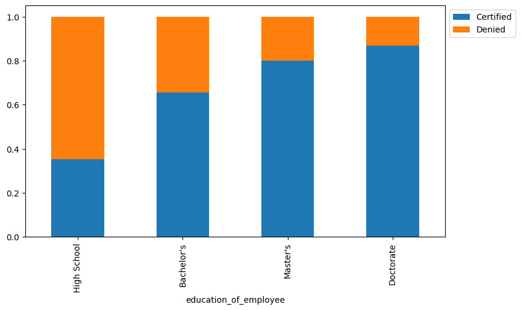

```python
# Get the visa applications where the unit of wage is year
data_wage_year = data[data['unit_of_wage'] == 'Year']

# Get the 70th percentile of the yearly wages
prevailing_wage_year_q75 = data_wage_year.prevailing_wage.quantile(0.7)

# Create stacked bar plots to observe visa certification or denial across different education levels for top 30% yearly prevailing wages
stacked_barplot(data_wage_year[data_wage_year.prevailing_wage > prevailing_wage_year_q75], 'education_of_employee', 'case_status')
```

##### Visa certifications for well-paid jobs with monthly unit of wage

```
case_status            Certified  Denied  All  Certified_Percent  Denied_Percent
education_of_employee
All                           17      10   27            0.62963         0.37037
Master's                       6       6   12            0.50000         0.50000
High School                    1       3    4            0.25000         0.75000
Bachelor's                     9       1   10            0.90000         0.10000
Doctorate                      1       0    1            1.00000         0.00000
------------------------------------------------------------------------------------------------------------------------
```

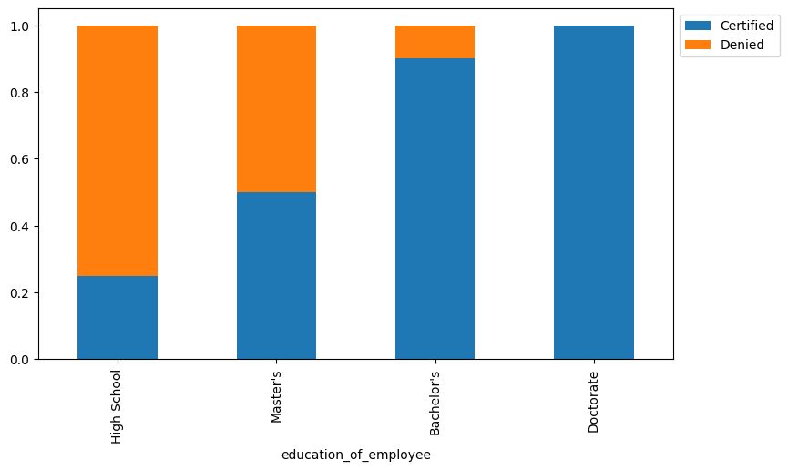

```python
# Get the visa applications where the unit of wage is month
data_wage_month = data[data['unit_of_wage'] == 'Month']

# Get the 70th percentile of the monthly wages
prevailing_wage_month_q75 = data_wage_month.prevailing_wage.quantile(0.7)

# Create stacked bar plots to observe visa certification or denial across different education levels for top 30% monthly prevailing wages
stacked_barplot(data_wage_month[data_wage_month.prevailing_wage > prevailing_wage_month_q75], 'education_of_employee', 'case_status')
```

For the visa applications with top 30% of the monthly prevailing wages,

- Visa applicants with Doctorate degree had the maximum % of visa certifications, at 100%
- Visa applicants with only High School education had the minimum % of visa certifications, at 25%

##### Visa certifications for well-paid jobs with weekly unit of wage

```
case_status            Certified  Denied  All  Certified_Percent  Denied_Percent
education_of_employee
All                           54      28   82           0.658537        0.341463
Bachelor's                    23      15   38           0.605263        0.394737
Master's                      25       9   34           0.735294        0.264706
High School                    5       4    9           0.555556        0.444444
Doctorate                      1       0    1           1.000000        0.000000
------------------------------------------------------------------------------------------------------------------------
```

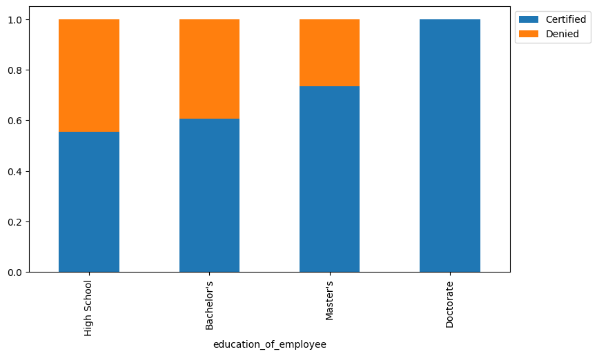

```python
# Get the visa applications where the unit of wage is week
data_wage_week = data[data['unit_of_wage'] == 'Week']

# Get the 70th percentile of the weekly wages
prevailing_wage_week_q75 = data_wage_week.prevailing_wage.quantile(0.7)

# Create stacked bar plots to observe visa certification or denial across different education levels for top 30% weekly prevailing wages
stacked_barplot(data_wage_week[data_wage_week.prevailing_wage > prevailing_wage_week_q75], 'education_of_employee', 'case_status')
```

For the visa applications with top 30% of the weekly prevailing wages,

- Visa applicants with Doctorate degree had the maximum % of visa certifications, at 100%
- Visa applicants with only High School education had the minimum % of visa certifications, at about 55.5%

##### Visa certifications for well-paid jobs with hourly unit of wage

```
case_status            Certified  Denied  All  Certified_Percent  Denied_Percent
education_of_employee
All                          228     419  647           0.352396        0.647604
Master's                      97     108  205           0.473171        0.526829
Bachelor's                    78     214  292           0.267123        0.732877
High School                   35      85  120           0.291667        0.708333
Doctorate                     18      12   30           0.600000        0.400000
------------------------------------------------------------------------------------------------------------------------
```

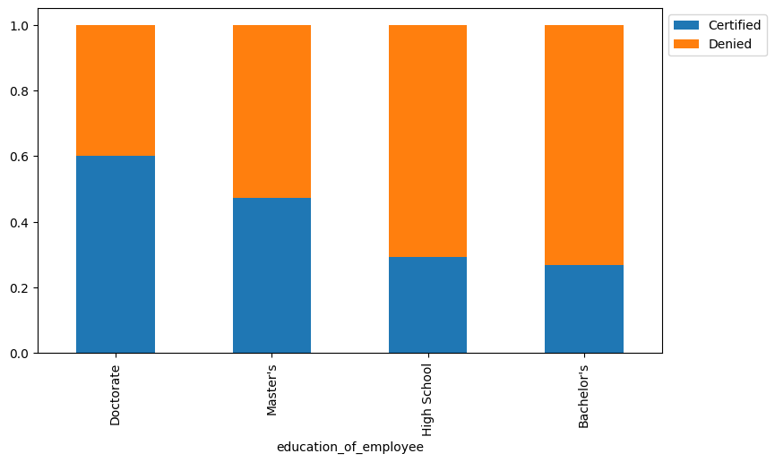

```python
# Get the visa applications where the unit of wage is hour
data_wage_hour = data[data['unit_of_wage'] == 'Hour']

# Get the 70th percentile of the hourly wages
prevailing_wage_hour_q75 = data_wage_hour.prevailing_wage.quantile(0.7)

# Create stacked bar plots to observe visa certification or denial across different education levels for top 30% hourly prevailing wages
stacked_barplot(data_wage_hour[data_wage_hour.prevailing_wage > prevailing_wage_hour_q75], 'education_of_employee', 'case_status')
```

For the visa applications with top 30% of the hourly prevailing wages,

- Visa applicants with Doctorate degree had the maximum % of visa certifications, at 60%
- Visa applicants with Bachelor's degree had the minimum % of visa certifications, at about 27%
- Overall certifications for applications with hourly unit of prevailing wages are less compared to certifications for applications with other units of prevailing wages